# Intro to Data Manipulation/Wrangling

Wed Oct 12, 2016

## Switching Gears

With the internet, we are in a new age of data:

[figure not shown]

## Bridging the Gap

- Meet Jenny Bryan at UBC: [GitHub](https://github.com/jennybc) profile
- She teaches a graduate level class [STAT 545](http://stat545.com/) on **Data wrangling, exploration, and analysis with R**. Note the ordering.

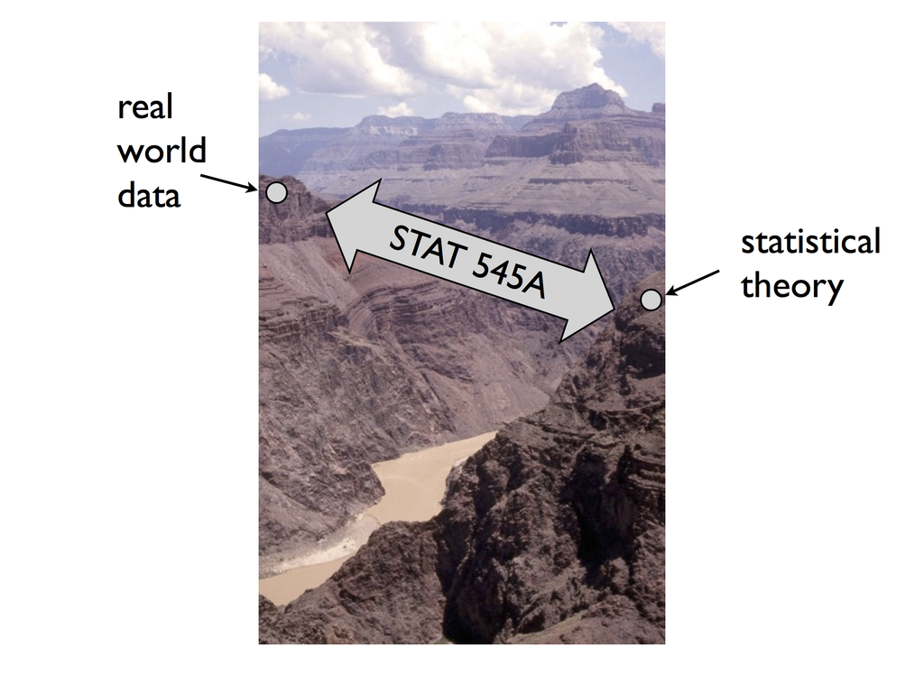

## Classroom vs Real Data

Jenny Bryan said: *"Classroom data are like teddy bears and real data are like a grizzly bear with salmon blood dripping out its mouth."*

Traditional Classroom Data

Real Data

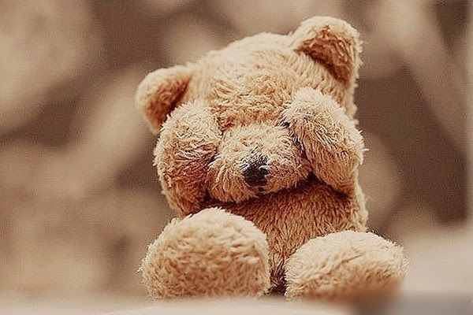

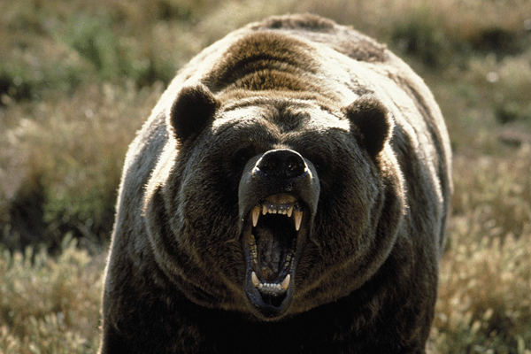

## Real Data

Some attributes of real data:

- Often not in a format ready for analysis
- Messy and needs cleaning
- Typos, weird outliers
- Missing values
- Inconsistent formatting

## Real Data

Inconsistent formatting is a real pain:

- Dates: "2016/10/12" vs "2016-10-12" vs "10/12/16" vs "10/12/2016" vs "Oct 12, 2016"
- "DC" vs "D.C." vs "District of Columbia"
- "Beyonce" vs "Beyoncé"

## dplyr Package

To take this, we now officially introduce the `dplyr` package: a grammar of data manipulation

[figure not shown]

## Pedogical Note

Were it not for this package, I probably wouldn't be taking a data-centric view to this course.

**Why do I have a `dplyr` sticker on my laptop? Why is `dplyr` so good IMO?**

- The **verb** describing the action you want to perform on your data **IS** the name of the `function()` you use.
- So you don't need extensive programming experience (indexing, for loops, etc) to be able to manipulate data.

## 5MV

Say hello to the 5MV: the **five main verbs**

1. `select()` columns by variable name
2. `filter()` rows matching criteria
3. `mutate()` existing variables to create new ones
4. `arrange()` rows
5. `summarise()` numerical variables that are `group_by()` categorical variables
6. Also, later `_join()` two separate data frames `by` corresponding variables

## Today:

1. `select()` columns by variable name: front of cheatsheet, bottom right
2. `filter()` rows matching criteria: front of cheatsheet, bottom middle. We've already used this in Chapter 3 on Data Viz.

Keep looking back and forth between book and cheatsheet!